# Week 2: Distributions and proportions

Carole Voulgaris

9/10/2020

For this assignment, you’ll be using the following libraries, so make sure they’re installed ahead of time.

```r
library(tidycensus)
library(tidyverse)
library(ggplot2)
```

Let’s start by loading the person-level dataset we created last week.

`read_csv()` loads the data into our environment and `attach` basically activates it so that when we refer to one of the variable in that dataframe, it knows which dataframe to look for it in.

```r
person_data <- read_csv("people.csv")
attach(person_data)
```

## Distribution of a continuous variable

```r
summary(JWMNP)
```

```
##    Min. 1st Qu.  Median    Mean 3rd Qu.    Max.
##    1.00   13.00   20.00   26.46   30.00  161.00
```

I can also use the functions `mean()` and `quantile()` to get these pieces separately. We can also use `sd()` to get the sample standard deviation, which isn’t included in the output of the `summary()` function.

```r
paste("The sample mean for the travel time to work is",
      prettyNum(mean(JWMNP), digits = 0), "minutes.")
```

```
## [1] "The sample mean for the travel time to work is 26 minutes."
```

```r
paste("The sample median for the travel time to work is",
      prettyNum(median(JWMNP), digits = 0), "minutes.")
```

```
## [1] "The sample median for the travel time to work is 20 minutes."
```

```r
paste("The sample standard deviation for the travel time to work is",
      prettyNum(sd(JWMNP), digits = 0), "minutes.")
```

```
## [1] "The sample standard deviation for the travel time to work is 23 minutes."
```

```r
paste("The sample interquartile range for the travel time to work is",
      quantile(JWMNP)["25%"], "to", quantile(JWMNP)["75%"], "minutes.")
```

```
## [1] "The sample interquartile range for the travel time to work is 13 to 30 minutes."
```

All of the above are characteristics of the sample. We can use t.test() to get a 95-percent confidence interval for the population mean.

```r
pop_mean <- t.test(JWMNP)

pop_mean
```

```
##
##  One Sample t-test
##
## data:  JWMNP
## t = 395.39, df = 115256, p-value < 2.2e-16
## alternative hypothesis: true mean is not equal to 0
## 95 percent confidence interval:
##  26.33139 26.59374
## sample estimates:
## mean of x
##  26.46257
```

```r
paste("The 95-percent confidence interval for the population mean is",
      prettyNum(pop_mean$conf.int[1], digits = 0), "to",
      prettyNum(pop_mean$conf.int[2], digits = 0), "minutes.")
```

```
## [1] "The 95-percent confidence interval for the population mean is 26 to 27 minutes."
```

We can get a quick look at that distribution by creating a histogram. We’ll use the ggplot2 package for all our graphics. I’ll save the graph to an object called `hist`, so I can add to it a little bit later.

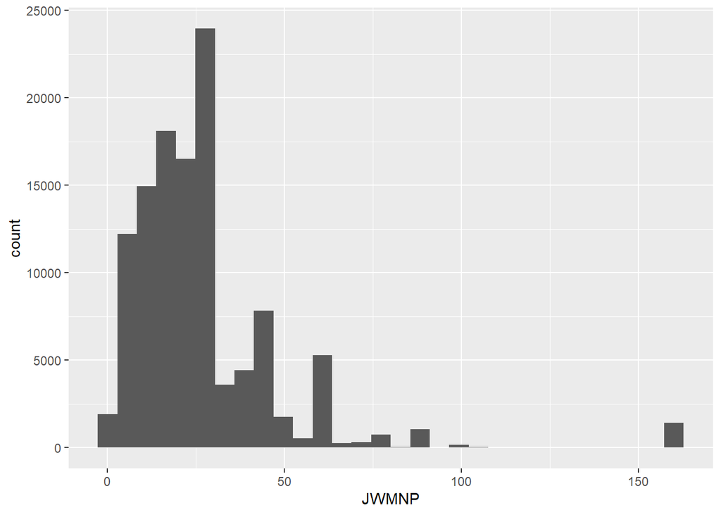

```r
hist <- ggplot(person_data, aes(x = JWMNP)) +
  geom_histogram()

hist
```

Let’s pretty up that histogram a little, and display the summary statistics we just calculated right on the figure.

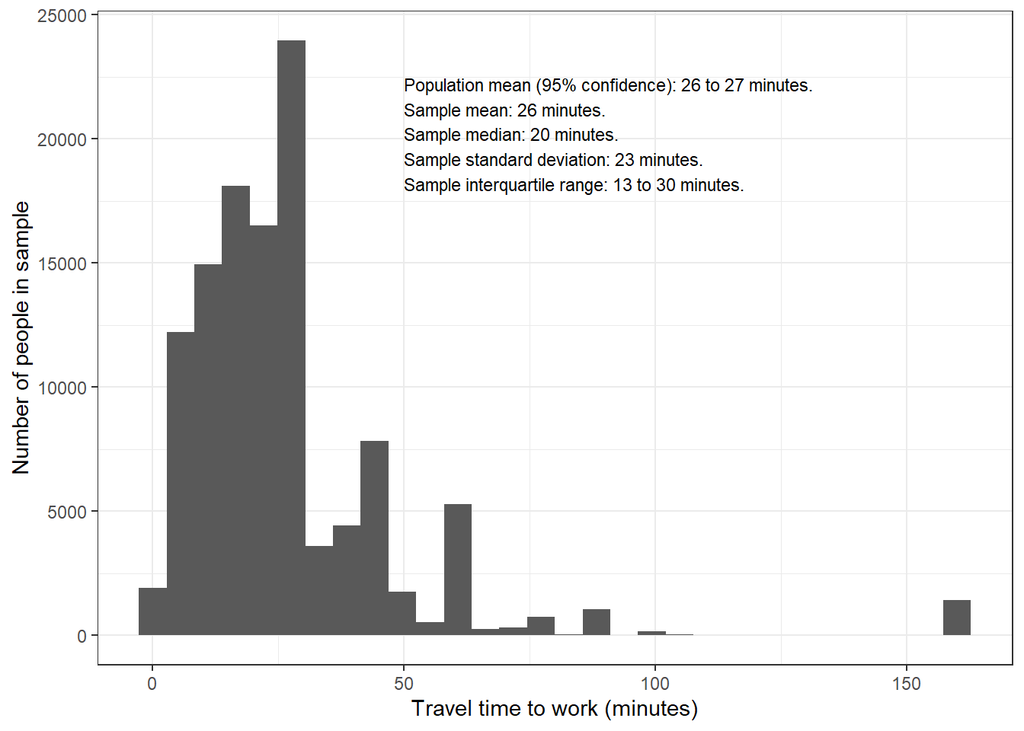

```r
hist +
  theme_bw() +
  scale_x_continuous(name = "Travel time to work (minutes)") +
  scale_y_continuous(name = "Number of people in sample") +
  annotate("text", x = 50, y = 22500, size = 3,
           label = paste("Population mean (95% confidence):",
                         prettyNum(pop_mean$conf.int[1], digits = 0),
                         "to",
                         prettyNum(pop_mean$conf.int[2], digits = 0),
                         "minutes.",
                         "\nSample mean:",
                         prettyNum(mean(JWMNP), digits = 0), "minutes.",
                         "\nSample median:",
                         prettyNum(median(JWMNP), digits = 0), "minutes.",
                         "\nSample standard deviation:",
                         prettyNum(sd(JWMNP), digits = 0), "minutes.",
                         "\nSample interquartile range:",
                         prettyNum(quantile(JWMNP)["25%"], digits = 0),
                         "to",
                         prettyNum(quantile(JWMNP)["75%"], digits = 0),
                         "minutes."),
           hjust = 0, vjust = 1)
```

## Distribution of a categorical variable

The distribution of a categorical variable can be decribed in terms of the proportion of the sample or population that falls in each category. Let’s take a look at the housing tenure variable (`TEN_label`).

First, we can get a list of all the possible values

```r
tenures <- unique(TEN_label)

tenures
```

```
## [1] "N/A (GQ/vacant)"
## [2] "Owned free and clear"
## [3] "Owned with mortgage or loan (include home equity loans)"
## [4] "Rented"
## [5] "Occupied without payment of rent"
```

Now let’s get the share of the sample in each category.

```r
group_quarters <- t.test(TEN_label == tenures[1])
owned_free <- t.test(TEN_label == tenures[2])
mortgage <- t.test(TEN_label == tenures[3])
rented <-  t.test(TEN_label == tenures[4])
rent_free <-  t.test(TEN_label == tenures[5])

shares <- tibble(Tenure = c("Group Quarters",
                            "Owned\nfree and clear",
                            "Owned\nwith mortgage",
                            "Rented",
                            "Occupied\nrent-free"),
                 `Share` = c(group_quarters$estimate,
                             owned_free$estimate,
                             mortgage$estimate,
                             rented$estimate,
                             rent_free$estimate),
                 Low = c(group_quarters$conf.int[1],
                         owned_free$conf.int[1],
                         mortgage$conf.int[1],
                         rented$conf.int[1],
                         rent_free$conf.int[1]),
                 High = c(group_quarters$conf.int[2],
                         owned_free$conf.int[2],
                         mortgage$conf.int[2],
                         rented$conf.int[2],
                         rent_free$conf.int[2]))
shares
```

```
## # A tibble: 5 x 4
##   Tenure                   Share     Low   High
##   <chr>                    <dbl>   <dbl>  <dbl>
## 1 "Group Quarters"        0.0103 0.00972 0.0109
## 2 "Owned\nfree and clear" 0.250  0.248   0.253
## 3 "Owned\nwith mortgage"  0.436  0.433   0.439
## 4 "Rented"                0.289  0.286   0.292
## 5 "Occupied\nrent-free"   0.0148 0.0141  0.0155
```

Now that we’ve calculated the confidence intervals for those proportions, and organized them into a dataframe, we can illustrate those results with a bar chart.

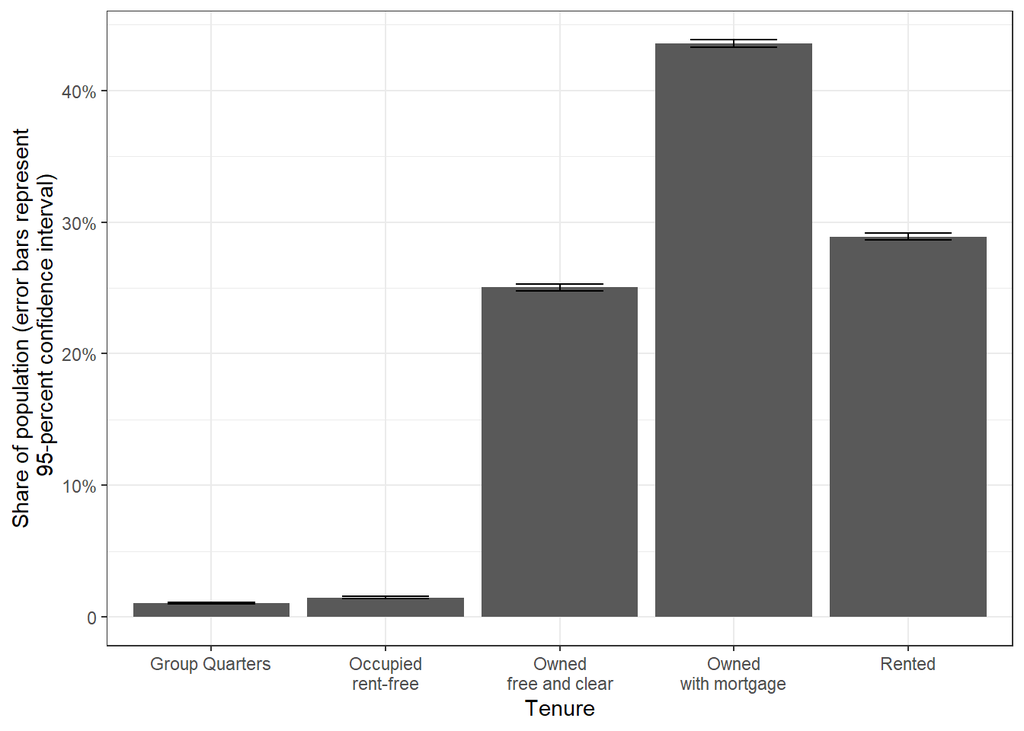

```r
ggplot(shares, aes(x = Tenure, y = Share, ymin = Low, ymax = High)) +
  geom_bar(stat = "identity") +
  geom_errorbar(width = 0.5) +
  theme_bw() +
  scale_y_continuous(name = "Share of population (error bars represent\n 95-percent confidence interval)",
                     breaks = c(0, 0.1, 0.2, 0.3, 0.4, 0.5),
                     labels = c("0", "10%", "20%", "30%", "40%", "50%"))
```